# Covid-19 Cases in South Africa

AS2019370 / I.M.G.U.K.Herath

10/6/2022

## 1. Introduction

### 1.1 About South Africa

South Africa is a country on the southernmost tip of the African continent, marked by several distinct ecosystems. Inland safari destination Kruger National Park is populated by big game. The Western Cape offers beaches, lush winelands around Stellenbosch and Paarl, craggy cliffs at the Cape of Good Hope, forest and lagoons along the Garden Route, and the city of Cape Town, beneath flat-topped Table Mountain

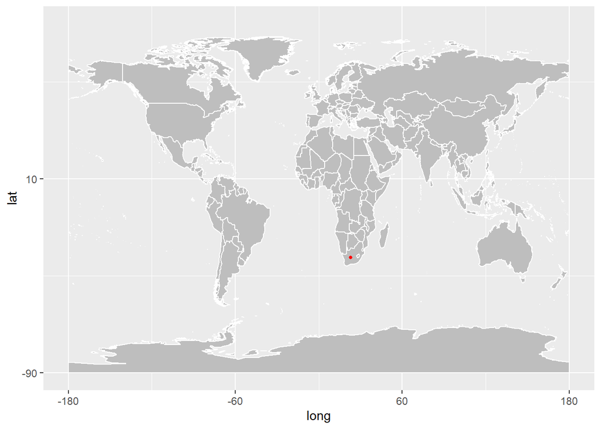

*Figure 1* : South Africa in World Map

### 1.2 Covid Cases in South Africa

On 5 March 2020, Minister of Health Zweli Mkhize had confirmed the spread of the virus to South Africa, with the first known patient being a citizen who tested positive upon his return from Italy.

Since then they have deal with total 4,017,700 confirmed positove cases, 102,185 number of death cases. Further they have 3,909,764 number of recoveries and conducted 21,172,787 number of tests and administrates 37,634,853 vaccines.

This report discusses how the corona virus cases(total Confirmed cases, Death cases and Recovery cases) fluctuated during the time period from January 2020 to June 2022.

## 2. Exploratory Data Analysis

### 2.1 Summary measures

Summary measures of total Confirmed cases, Death cases and Recovery cases are as given below.

- **Confirmed cases**

```
   Min. 1st Qu.  Median    Mean 3rd Qu.    Max.
    0.0   901.5  2111.5  4513.6  6555.0 37875.0
```

```
[1] "Total confirmed cases =" "3990057"
```

- **Death cases**

```
   Min. 1st Qu.  Median    Mean 3rd Qu.    Max.
    0.0    18.0    65.0   115.6   154.2   844.0
```

```
[1] "Total death cases =" "102160"
```

- **Recovery cases**

```
   Min. 1st Qu.  Median    Mean 3rd Qu.    Max.
      0       0     407    2558    2665   45858
```

```
[1] "Total recovery cases =" "2261158"
```

### 2.2 Graphical Visualization of COVID-19 cases in South Africa

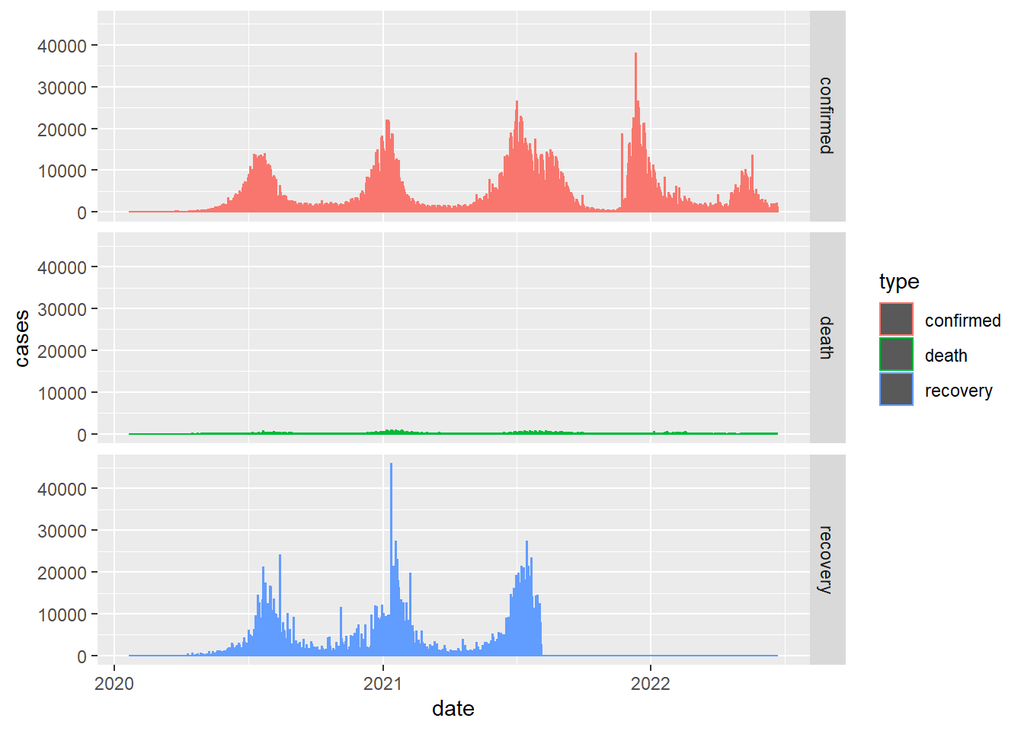

*Figure 2* : Daily COVID-19 cases fluctuation over Time by case type

### 2.3 Active COVID-19 cases in South Africa

```
[1] "Current COVID-19 cases=" "1626739"
```

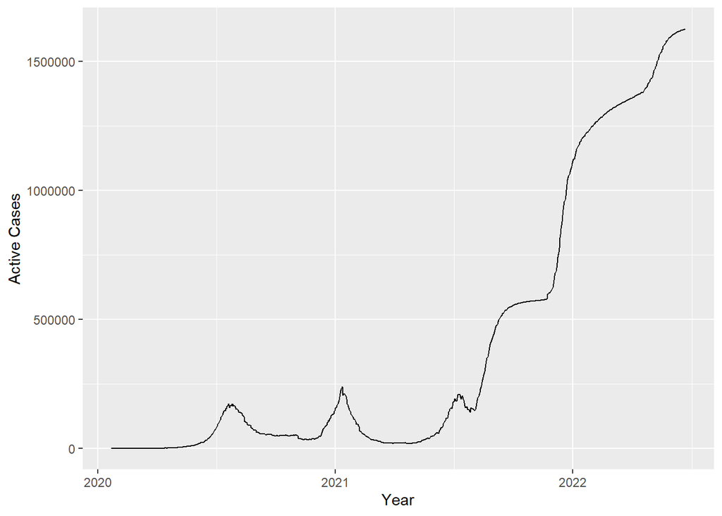

*Figure 3* : Active COVID-19 cases of South Africa over Time

According to above plot Active COVID-19 cases are increasing over time.

### 2.4 Comparison of COVID-19 cases of South Africa with other Countries

Its hard to come to an accurate image on the COVID-19 cases by only looking at the COVID-19 cases in South Africa alone.Therefore,here the COVID-19 cases in South Africa is compared with the countries Ghana, Zambia and Zimbabwe which are in the same geographical region with South Africa.

- **COVID-19 cases in Ghana**

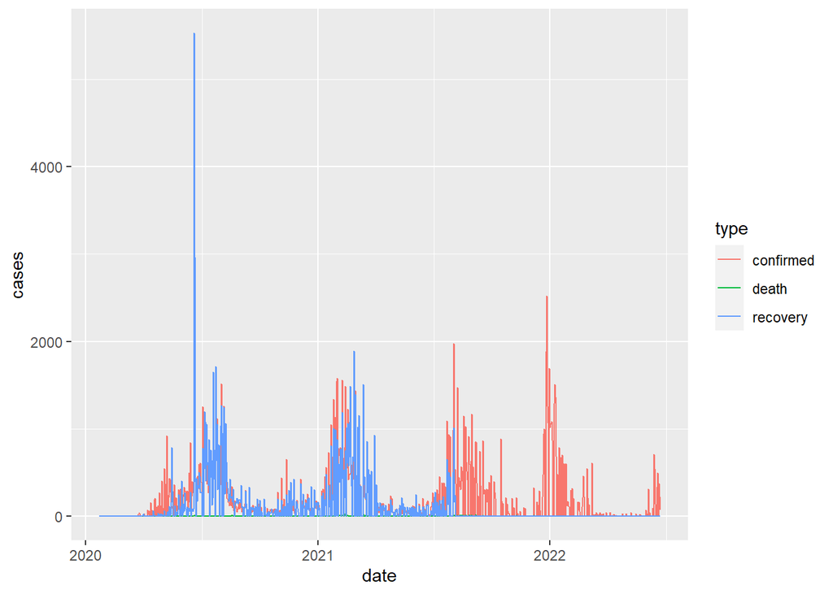

  *Figure 4* : Daily COVID-19 cases fluctuation of Ghana over Time by case type

- **COVID-19 cases in Zambia**

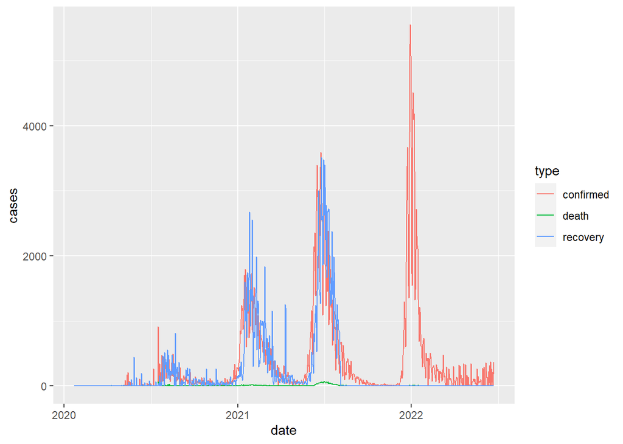

  *Figure 5* : Daily COVID-19 cases fluctuation of Zambia over Time by case type

- **COVID-19 cases in Zimbabwe**

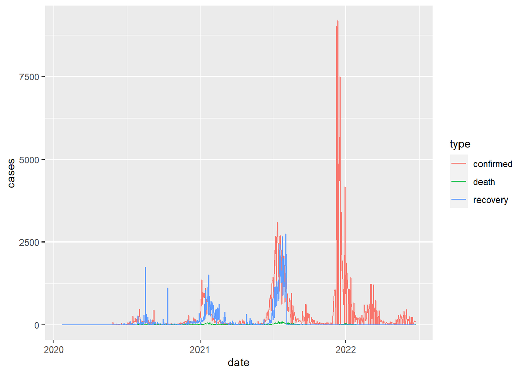

  *Figure 6* : Daily COVID-19 cases fluctuation of Zimbabwe over Time by case type

  By looking at the *Figure 4, Figure 5, Figure 6* for all these three countries we can see from 2020 to mid 2021 the confirmed cases and recovered cases are seems to be equal.But after mid 2021 the confirmed cases are highly increasing and the recovery cases becomes negligible. Further all the time death cases are seems to be negligible.

#### Comparison COVID-19 cases in South Africa with other countries

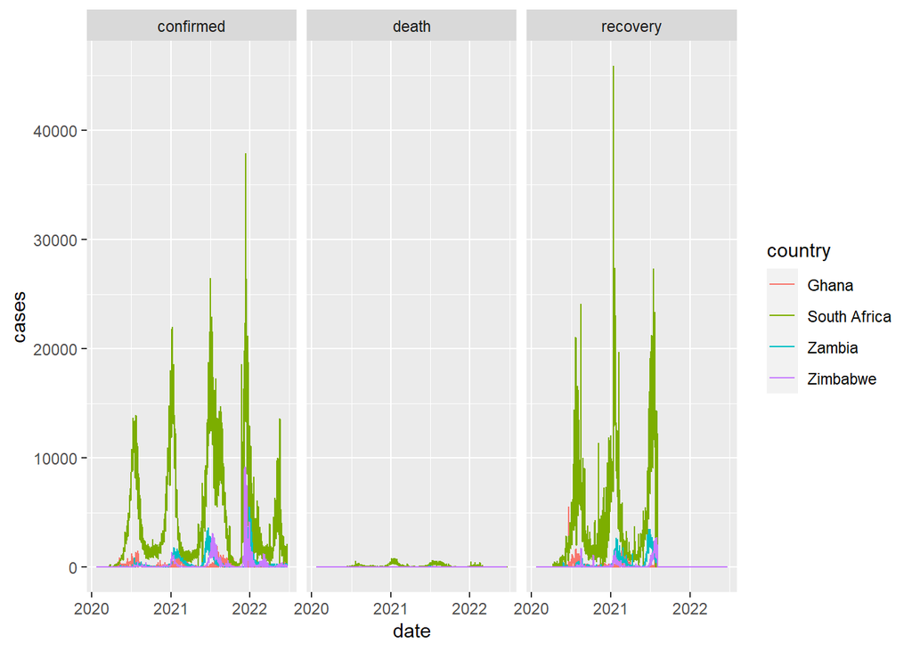

*Figure 7* : Daily COVID-19 cases fluctuation of all 4 counties over Time by Case Type

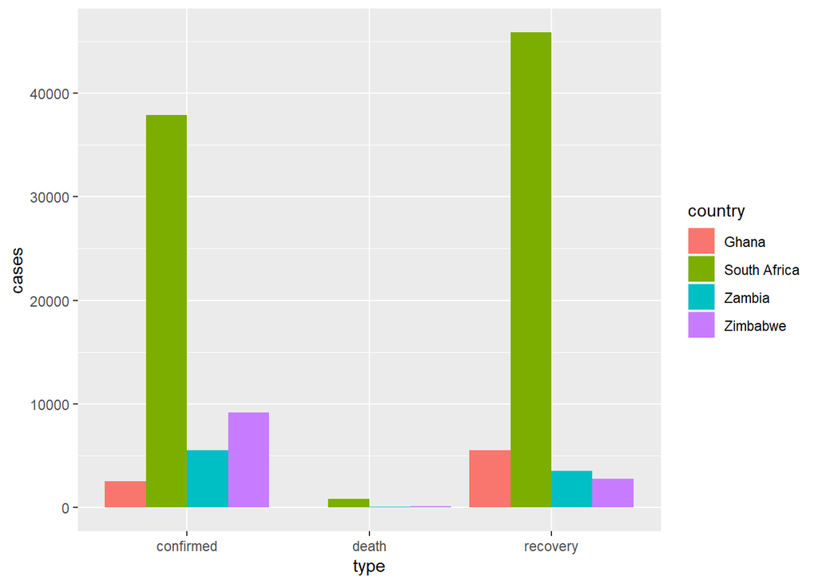

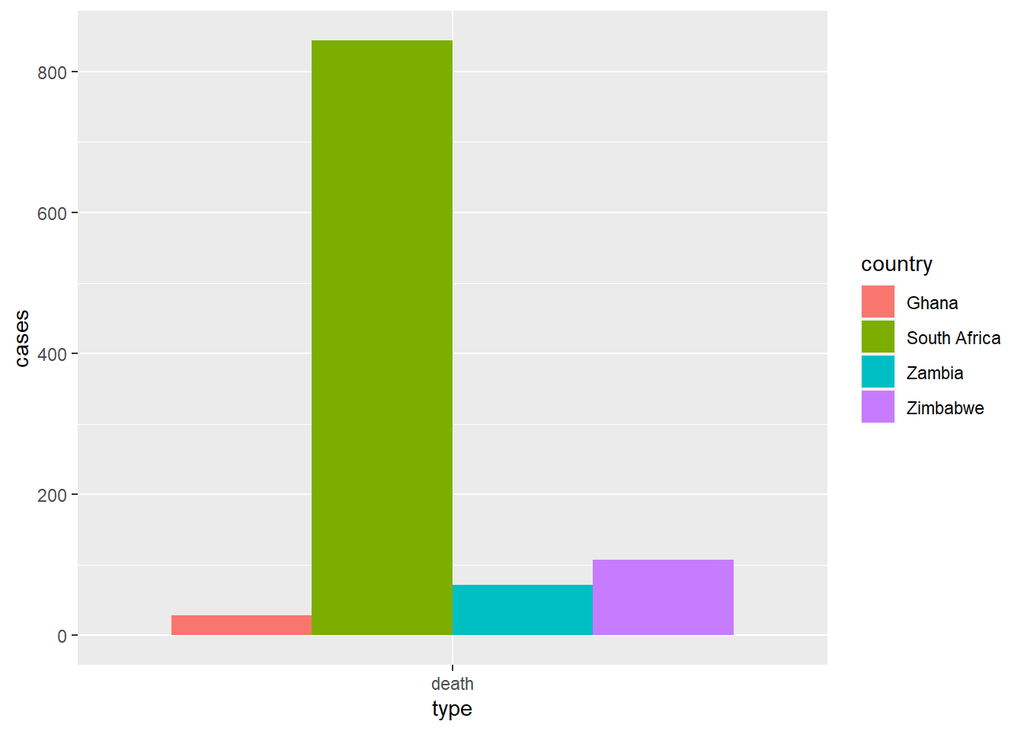

*Figure 7, Figure 8 and Figure 9* shows that the all 3 cases(*confirmed,recovery and death*) are higher in South Africa comparing to other countries.However the death cases are always negligible comparing to other two cases.

### 3. Conclusion

Furthermore as COVID-19 death cases of South Africa are negligible comparing to Confirmed COVID-19 cases it is clear that government in South Africa had somehow successfully managed the COVID-19 pendamic.

But unfortunately as shown in *Figure 3* the Active Cases of COVID-19 has increased over time. So the threat is still there(currently there is 1626739 Active cases). The government should also concern how to decrease these active cases.

### 4. References

- https://en.wikipedia.org/wiki/COVID-19_pandemic_in_South_Africa
- https://sacoronavirus.co.za/